# Examen

[figure not shown]

## Examen

[figure not shown]

*Rommel Juarez* https://github.com/RommelJuarez/machine-learning/tree/master/pruebas

```python
# Your imports HERE !!!!
import numpy as np
import pandas as pd
import matplotlib.pyplot as plt
```

## 01 - 1 pt

- Dado un array de elementos, escribir una función, que reciba dicho array como parámetro de entrada y devuelva el elemento repetido. Usando plain Python, sin ninguna librería.

```python
array_src = [4, 8, 0, 3, 6, 2, 1, 5, 3, 9, 7]
expected_rep_element = 3
rep_element = repeated_element(array_src) # This calls your function repeated_element
assert(expected_rep_element == rep_element)  # This will fail if the element is not found correctly
```

```
3
```

```python
# Your solution HERE !!!!
def repeated_element(array):
    numeros_vistos=set()
    for numero in array:
        if numero in numeros_vistos:
            print(numero)
            return numero
        numeros_vistos.add(numero)
```

## 02 - 1pt

- Genera una matriz con valores aleatorios de 0 a 100 de dimensiones 16x16
- Calcula los siguentes estadísticos en la matriz anterior, por fila (el resultado de cada uno debe ser un array de dimensiones 1x16)
  - Suma de los elementos de cada fila
  - Media de los elementos de cada fila
  - Valores mínimos de cada fila
  - Valores máximos de cada fila

```python
# Your solution HERE !!!!
matrix=np.random.randint(0, 101, size=(16, 16))
print(matrix)
print("suma:",np.sum(matrix,axis=1))
print("media:",np.median(matrix,axis=1))
print("valores min:",np.min(matrix,axis=1))
print("valores max:",np.max(matrix,axis=1))
```

```
[[ 84  66  44  24  65  91   0  54  33  77  90  56  57   9  50  92]
 [ 95  63  40  85  75  99  97  26  16  12  78  69  15  26  43  24]
 [ 16  83  54  49  14  57  27  92  53  17  48  84  64  64  29  93]
 [ 42  78   5  41  94  89  59  74  97  70  94  33  70  61  90  34]
 [ 96  65   0  56  67   8  70  83  88  59  22   2  99   6  76  95]
 [ 21  86  77  31  63   6  87 100  96  36 100  52   0  83  96  36]
 [ 36  61  97  10  14  83  57  75  39  29 100  77  10  86  14  46]
 [  2  31  80  24  33  70  72  21  96  33  58   2  48  17  97  15]
 [ 62  55  50  19   7  30  69  83   3   6  96  25  43  45  74  36]
 [ 43  57  15  57  74   7  74  42   7   8  94  26  77   7  71  10]
 [ 36  44  28  95  50  93  14  16  96  29  69  43  52  58  22  37]
 [ 89  36   1  82  70  91  95  95  56  21 100  29  39 100  45  20]
 [ 14  21  96  71  94  37  95  16  38  90  49  10  41  38  96  74]
 [ 74  11  49   3  34  38  51  17  96  70  95  71  41  38  66  64]
 [ 10   6   2  42  40  46  35  31  26  99  81   4  50   0   2  10]
 [  3   0  85  83   0  76  60  90  10  15  22  86  21  70  33  81]]
suma: [ 892  863  844 1031  892  970  834  699  703  669  782  969  880  818
  484  735]
media: [56.5 53.  53.5 70.  66.  70.  51.5 33.  44.  42.5 43.5 63.  45.  50.
 28.5 46.5]
valores min: [ 0 12 14  5  0  0 10  2  3  7 14  1 10  3  0  0]
valores max: [ 92  99  93  97  99 100 100  97  96  94  96 100  96  96  99  90]
```

## 03 - 1pt

- Generar un dataframe de 3x4 dimensiones con valores númericos aleatorios [0,10]
- Darle un índice semántico alfanumérico
- Aplicarle una función lambda que obtenga la diferencia entre el máximo y mínimo de cada fila

```python
# Your solution HERE !!!!
df=pd.DataFrame(np.random.randint(0,11,size=(3,4)),index=(1,2,3),columns=list('abcd'))
display(df)
resultado=(lambda x:(np.max(x,axis=1)) - ( np.min(x,axis=1)))(df)
display(resultado)
```

|  | a | b | c | d |
| --- | --- | --- | --- | --- |
| 1 | 10 | 1 | 9 | 7 |
| 2 | 2 | 1 | 5 | 10 |
| 3 | 4 | 6 | 1 | 2 |

```
1    9
2    9
3    5
dtype: int32
```

## 04 - 1pt

- Crear un array de NumPy de dimensiones 8x5, con números enteros aleatorios en el rango [-100, 100]
- Ejecutar en este orden
  1. Reemplazar los valores de todos aquellos números múltiplos de 5 por 100
  2. Reemplazar los valores de todos aquellos números múltiplos de 3 por Nan
  3. Averiguar cuantos elementos tienen Nan por fila
  4. Reemplazar los valores de Nan por 0

```python
# Your solution HERE !!!!
arrayR=np.random.randint(-100, 101, size=(8, 5))
arrayR = arrayR.astype(float)
arrayR[arrayR % 3==0] = np.nan
arrayR[arrayR % 5==0] = 100
print("array con nulos y 100")
print(arrayR)
nulos_fila= np.isnan(arrayR).sum(axis=1)
print("nulos por fila: ",nulos_fila)
ceros=np.where(np.isnan(arrayR), 0, arrayR)
print("array con 0 en vez de nulos")
print(ceros)
```

```
array con nulos y 100
[[-73.  94.  nan 100.  76.]
 [ nan -31.  nan  92. -37.]
 [ 38.   4. 100. -92.  nan]
 [ 19.  64.  nan -17.  nan]
 [ nan  nan   8.  16.  82.]
 [ 92.  79.   7.  nan 100.]
 [100.  38.  nan 100. 100.]
 [100.  94. -83. -97.  nan]]
nulos por fila:  [1 2 1 2 2 1 1 1]
array con 0 en vez de nulos
[[-73.  94.   0. 100.  76.]
 [  0. -31.   0.  92. -37.]
 [ 38.   4. 100. -92.   0.]
 [ 19.  64.   0. -17.   0.]
 [  0.   0.   8.  16.  82.]
 [ 92.  79.   7.   0. 100.]
 [100.  38.   0. 100. 100.]
 [100.  94. -83. -97.   0.]]
```

## 05 - 1pt

- Crear una función que reciba una lista de strings y devuelva una serie de pandas, y convierta el primer y último carácter de la palabra de cada elemento de la serie a mayúsculas

```python
languages = ['python', 'php', 'java', 'javascript', 'c++', 'sql']
expected_output = pd.Series(['PythoN', 'PhP', 'JavA', 'JavascripT', 'C++', 'SqL'])
output = first_last_uppercase(languages)
print(output)  # This calls your function first_last_uppercase
assert(expected_output.equals(output))  # This will fail if the two lists are different
# Your solution HERE !!!!
```

```
0        PythoN
1           PhP
2          JavA
3    JavascripT
4           C++
5           SqL
dtype: object
```

```python
# Your solution HERE !!!!
def first_last_uppercase(lenguajke):

    return pd.Series([lang[0].upper() + lang[1:-1] + lang[-1].upper() for lang in lenguajke])
```

## 07 - 1pt

- La serie de Fibonacci es una sucesión de números, en la cual cada número es la suma de los dos anteriores. Los dos primeros son siempre 0 y 1.
  - $F_0 = 0$
  - $F_1 = 1$
  - $F_n = F_{n-1} + F_{n-2}$
- Crear un generador infinito de números de Fibonacci.

```python
fibo = [0,1,1,2,3,5,8,13,21,34,55,89,144,233,377,610,987,1597]
g = fibonacci_generator()  # This calls tour function fibonacci_generator
expected_output = [next(g) for n in range(len(fibo))]
assert(fibo == expected_output)  # This will fail if the output is not as expected
```

```python
# Your solution HERE !!!!
def fibonacci_generator():
    a, b = 0, 1
    while True:
        yield a
        a, b = b, a + b
```

## 07 - 4pt

- Crear una lista de meses de Enero a Diciembre (eje X)
- Generar datos aleatorios para el eje Y, hacerlo 3 veces distintas (Y0, Y1 e Y2)
- Representar las 3 secuencias de datos aleatorios en una sola figura usando matplotlib
- Añadir una leyenda para poder identificar cada secuencia
- Nombrar las 3 secuencias de la siguiente manera ("Facebook", "Twitter", "Instagram")
- Añadir un título y nombres a los dos ejes
- Añadir una anotación (texto y flecha) a uno de los gráficos

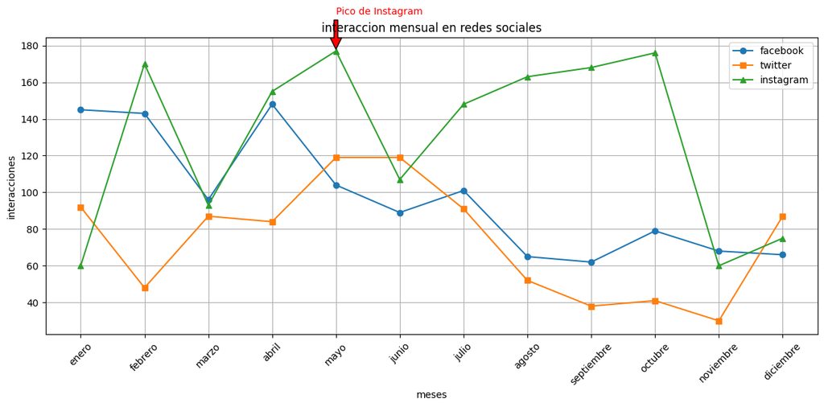

```python
# Your solution HERE !!!!
meses = ["enero","febrero","marzo","abril","mayo","junio","julio","agosto","septiembre","octubre","noviembre","diciembre"]
anio1 = np.random.randint(50, 150, size=12)
anio2 = np.random.randint(30, 120, size=12)
anio3 = np.random.randint(60, 180, size=12)
plt.figure(figsize=(12, 6))
plt.plot(meses, anio1, label="facebook", marker='o')
plt.plot(meses, anio2, label="twitter", marker='s')
plt.plot(meses, anio3, label="instagram", marker='^')
plt.legend()
plt.title("interaccion mensual en redes sociales")
plt.xlabel("meses")
plt.ylabel("interacciones")
max_idx = np.argmax(anio2)
plt.annotate('Pico de Instagram',
             xy=(meses[max_idx], anio3[max_idx]),
             xytext=(meses[max_idx], anio3[max_idx] + 20),
             arrowprops=dict(facecolor='red', shrink=0.05),
             fontsize=10, color='red')
plt.xticks(rotation=45)
plt.grid(True)
plt.tight_layout()
plt.show()
```